# Chapter 2

## Randomization

- When subjects are assigned to one of several groups with help of a random device we call this random allocation.
- This is useful not because this “balances” the group with respect to known covariates
- Instead, it insures that the expected outcome of the two groups would be the same, if they were to receive the same treatment
  - If this is the case, we call the groups exchangeable

The fundament of causal inference rests is not balance, but exchangeability of the treatment groups

## Notation

- $\small Y^a$: The *potential outcome* $\small Y$ (not observed) under treatment $\small a$
- $\small Pr[Y = 1| A = 1]$: The proportion of cases with the *observed outcome* $\small Y=1$, among those with the *observed treatment* $\small A=1$.
- $\small Pr[Y^a = 1| A = 0]$: The proportion with the *potential outcome for treatment* $\small Y^a$ being $\small 1$ , among those with the *observed treatment* $\small A = 0$.

## Exchangebility

If we want to estimate the effect $\small A \rightarrow Y$ as

$$\small \textrm{Effect} = Pr[Y = 1| A = 1] - Pr[Y = 1| A = 0]$$

This requires that the *potential outcome* of treatment $\small a$, $Y^a$, is equal for those *observed* with ($\small A=1$) and without ($\small A=0$) treatment.

$$\small Pr[Y^a=1|A=1] = Pr[Y^a=1|A=0]$$

## Exchangebility

If the potential outcomes are the same irrespective of the observed treatment ($\small Pr[Y^a=1|A=1] = Pr[Y^a=1|A=0]$), they are independent

$$Y^a \perp A$$

If the potential outcomes are independent of the treatment, we say the the treatment and the control group are *exchangeable* (wrt. to the potential outcomes) or that the treatment is *exogenous*.

## Exchangebility

- is an assumption that we need to calculate treatment as $ATE$s
- if we can justify this assumption, we can calculate treatment effects as the difference in the average outcome of the treated and the untreated.
- the assumption cannot be verified, but randomization produces exchangeability

## Randomization in action

Experiment with $\small Pr[Y^0, A=1] = 0.5, Pr[Y^1, A=1] = 0.8$

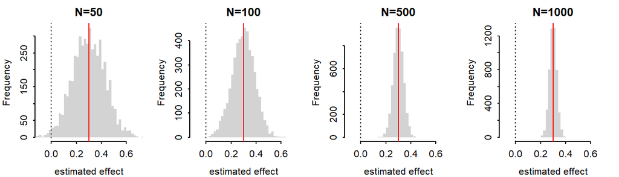

Randomization insures exchangeability for large N, or on average for many experiments. For small N experiments exchangeability is only an unverifiable assumptions!

## Conditional randomization

- without any qualifier, randomization is assumed to mean *marginal randomization*: All units are randomized equally  
  ($\small Pr[A=1|L=0] = Pr[A=1|L=1]$)
- in *conditional randomization* different strata $\small L$ are randomized according to different randomization schemes  
  ($\small Pr[A=1|L=0] \neq Pr[A=1|L=1]$)
- when strata $L$ are have different potential outcomes, $\small Pr[Y^{a=0}=1 | L=0] \neq Pr[Y^{a=0}=1 | L=1]$, potential outcomes of the treated and untreated will not be equal under *conditional randomization*: $Y^a \not\perp A$

## Conditional exchangeability

In conditional randomization, exchangeability is holds within $\small L$

$$\small Pr[Y^a=1|A=1,L=1] = Pr[Y^a=1|A=0,L=1]$$

conditional randomization induces independence of potential outcomes and treatment in the strata:

$$Y^a \perp A | L = 1 \textrm{ and } Y^a \perp A | L = 0$$

or short

$$Y^a \perp A | L$$

## Standardization

Calculate average risk in treatments, then effects

|  | $L=0$ | $L=1$ |
| --- | --- | --- |
| $A=0$ | $\small 1/4$ | $\small 4/6$ |
| $A=1$ | $\small 2/4$ | $\small 4/6$ |
|  | $\tiny n=8$ | $\tiny n=12$ |

$$\small RISK_{A=\color{Red}{1}} = 0.4\frac{2}{4}+0.6\frac{4}{6}=0.6 \\
\small RISK_{A=\color{Red}{0}} = 0.4\frac{1}{4}+0.6\frac{4}{6}=0.5 \\
\small ATE = 0.6/0.5 = 1.2$$

Generally:
$$\frac
{\sum_l Pr[Y=1|L=l,A=\color{Red}{1}]Pr[L=l]}
{\sum_l Pr[Y=1|L=l,A=\color{Red}{0}]Pr[L=l]}$$

## Standardization?

Calculate effects first in strata, then average effects

|  | $L=0$ | $L=1$ |
| --- | --- | --- |
| $A=0$ | $\small 1/4$ | $\small 4/6$ |
| $A=1$ | $\small 2/4$ | $\small 4/6$ |
|  | $\tiny n=8$ | $\tiny n=12$ |

$$\small ATE_{L=0} = \frac{2}{4}/\frac{1}{4}=2 \textrm{, }
ATE_{L=1} = \frac{4}{6}/\frac{4}{6}=1 \\
\small ATE = 0.4\cdot 2 + 0.6\cdot 1 = 1.4$$

## Inverse probability weighting

|  | $L=0$ | $L=1$ |
| --- | --- | --- |
| $A=0$ | $\small 1/4$ | $\small 4/6$ |
| $A=1$ | $\small 2/4$ | $\small 4/6$ |
|  | $\tiny n=8$ | $\tiny n=12$ |

$$\small Pr[Y^{a=0} = 1] = 2 \cdot 1 + 2 \cdot 4 = 10 \\
\small Pr[Y^{a=1} = 1] = 2 \cdot 2 + 2 \cdot 4 = 12 \\
\small ATE = 12 / 10 = 1.2$$

## Inverse probability weighting

[figure not shown]

Figure 2.3 from the book

> Informally, the pseudo-population is created by weighting each individual in the population by the inverse of the conditional probability of receiving the treatment level that she indeed received.